# Visualizing Geo-Science Results in 3D with ggcube

A ggcube tutorial — 3D scatter, multivariate scatter, DEM surface, bars and paths in R

Shuhao Li

2026-06-26

> This report is a hands-on tutorial for [**ggcube**](https://matthewkling.github.io/ggcube/), an R package (by Matthew Kling, on CRAN) that extends ggplot2 into three dimensions. When hydro-meteorological and geographic data carry **spatial location, a time process and a variable intensity** at once, a 3D view is often more expressive than a single 2D plot. ggcube keeps the ggplot2 layer grammar and adds 3D coordinates via `coord_3d()`, 3D geometric objects, lighting, projection and viewpoint control — so familiar ggplot2 code moves naturally into three dimensions. This page reproduces five core ggcube figures end to end.

# 1 Why 3D, and why ggcube

The idea behind `ggcube` is direct: **keep the ggplot2 layer grammar, but let 2D graphics move into 3D space.** It reuses `ggplot()`, `aes()`, `geom_*()` and `theme_*()`, then adds 3D coordinates, 3D geoms, lighting, projection and viewpoint control — so you never have to switch to a different plotting system. In short: **ggplot2 handles the layer logic, ggcube places those layers into three dimensions.** The main 3D layers used here:

| Plot type | ggcube function |
| --- | --- |
| 3D scatter | `geom_point_3d()` |
| 3D surface (DEM / continuous field) | `geom_surface_3d()` (with `light()`) |
| 3D bars (histogram / grid columns) | `geom_bar_3d()` / `geom_col_3d()` |
| 3D path (trajectory / space–time) | `geom_path_3d()` |
| 3D coordinate system | `coord_3d()` (view `yaw / pitch / roll`, distance `dist`, aspect `ratio`) |

# 2 Installation & setup

```r
# ggcube is on CRAN:
install.packages(c("rmarkdown","prettydoc","ggplot2","scales","ggcube"))  # 首次

# Or the development version from GitHub:
# install.packages("remotes")
# remotes::install_github("matthewkling/ggcube")
```

```r
library(ggplot2)
library(ggcube)
library(scales)
```

# 3 The simplest 3D scatter

The logic is clear: `displ` maps to the X axis, `hwy` to Y, `cty` to Z, and `class` distinguishes categories by colour. `geom_point_3d()` draws the three-dimensional points and `coord_3d()` establishes the 3D coordinate system. If you can already build an ordinary ggplot2 scatter plot, this needs almost no extra learning.

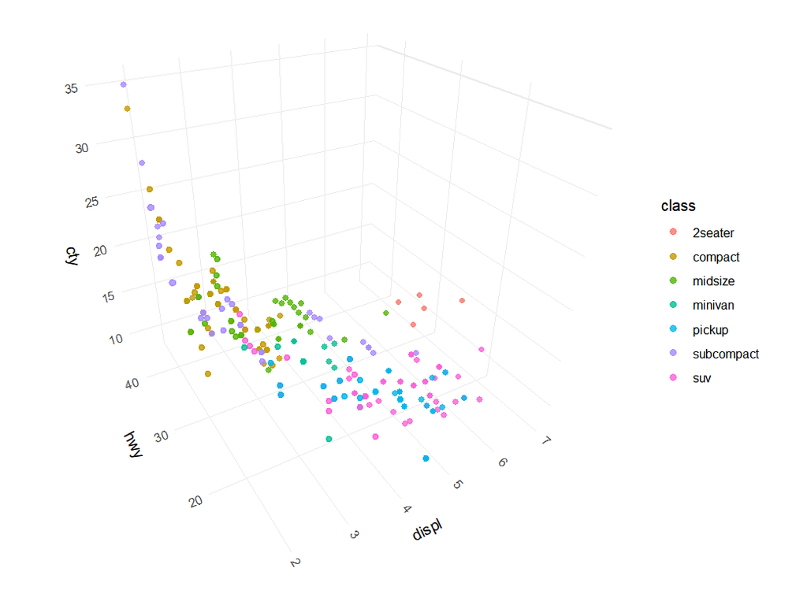

```r
p1 <- ggplot(mpg, aes(x = displ, y = hwy, z = cty, color = class)) +
  geom_point_3d(size = 2, alpha = 0.8) +
  coord_3d() +
  theme_minimal()
p1
```

# 4 A 3D scatter for multiple variables

A 3D scatter is well suited to showing the relationship between three continuous variables; adding colour, point size or transparency encodes a fourth. Here `lon` and `lat` represent spatial position, `time` represents the time step, and `intensity` represents an event strength such as heatwave or precipitation intensity — so a single figure captures how an event evolves across **four dimensions**.

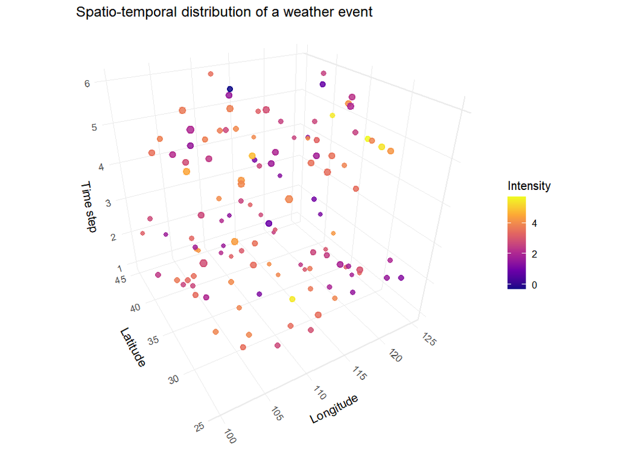

```r
set.seed(123)
weather_data <- data.frame(
  lon       = runif(120, 100, 125),
  lat       = runif(120, 25, 45),
  time      = sample(1:6, 120, replace = TRUE),
  intensity = rnorm(120, mean = 3, sd = 1)
)

p2 <- ggplot(weather_data, aes(x = lon, y = lat, z = time, color = intensity)) +
  geom_point_3d(size = 2.5, alpha = 0.85) +
  coord_3d() +
  scale_color_viridis_c(option = "C") +
  labs(
    x = "Longitude", y = "Latitude", z = "Time step",
    color = "Intensity",
    title = "Spatio-temporal distribution of a weather event"
  ) +
  theme_minimal()
p2
```

# 5 3D surfaces — a simulated DEM

Many geographic and environmental variables are themselves continuous surfaces: elevation (DEM), land-surface temperature, precipitation fields, water tables, pollutant concentration, soil moisture, model-error surfaces. A 2D heat map can show high and low areas, but the relief and gradients are not intuitive; a 3D surface shows peaks, valleys and continuous change directly.

Here a DEM over the China region (80–130°E, 20–55°N) is simulated: a **western massif** (Tibetan-Plateau style, peak ~3500 m), a **north-eastern secondary massif** (~1200 m) and a low-frequency undulation. `geom_surface_3d()` auto-detects the regular grid, tessellates it into a mesh, and `light()` applies terrain hillshading. In practice you simply swap `elevation` for a real DEM or any other continuous environmental variable.

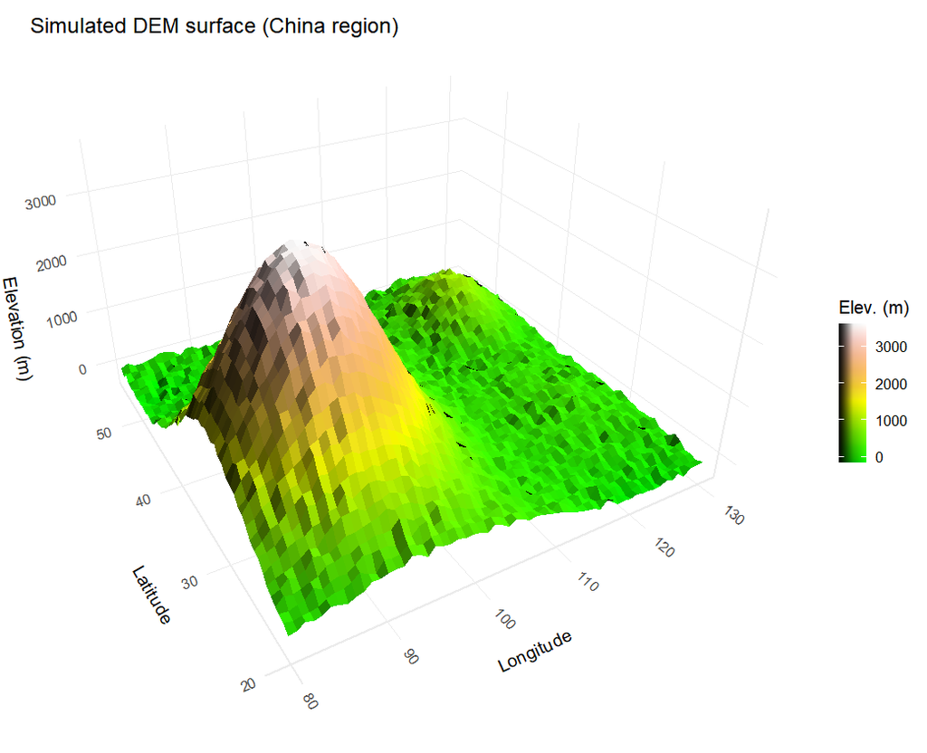

```r
set.seed(123)
lon_seq <- seq(80, 130, length.out = 60)
lat_seq <- seq(20, 55,  length.out = 60)

dem_data <- expand.grid(lon = lon_seq, lat = lat_seq)
dem_data$elevation <- with(
  dem_data,
  3500 * exp(-(((lon - 92) / 12)^2 + ((lat - 33) / 9)^2)) +   # western massif
  1200 * exp(-(((lon - 122) / 7)^2 + ((lat - 47) / 6)^2)) +   # north-eastern massif
  250  * sin(lon / 6) * cos(lat / 5) +                        # low-frequency undulation
  rnorm(length(lon), 0, 40)                                   # fine-scale noise
)

p3 <- ggplot(dem_data, aes(x = lon, y = lat, z = elevation,
                           fill = elevation, color = elevation)) +
  geom_surface_3d(
    light     = light(direction = c(1, 0, 0.5), mode = "hsv", contrast = 1.3),
    linewidth = 0.08
  ) +
  scale_fill_gradientn(colors = terrain.colors(10)) +
  scale_color_gradientn(colors = terrain.colors(10)) +
  coord_3d(ratio = c(1, 1, 0.6)) +
  # elevation is mapped to both fill (faces) and color (mesh lines), which would
  # create two identical legends — keep only the 3D fill colorbar, hide the color one
  guides(fill = guide_colorbar_3d(), color = "none") +
  labs(x = "Longitude", y = "Latitude", z = "Elevation (m)",
       fill = "Elev. (m)", title = "Simulated DEM surface (China region)") +
  theme_minimal() +
  theme(legend.position = "right")
p3
```

# 6 3D bars and columns

Beyond continuous variables, ggcube can also draw 3D bar charts — useful for comparisons across sites, months, years or scenarios.

**`geom_bar_3d()`** is a 2D histogram: it takes two continuous variables on x / y and counts the z (frequency) automatically.

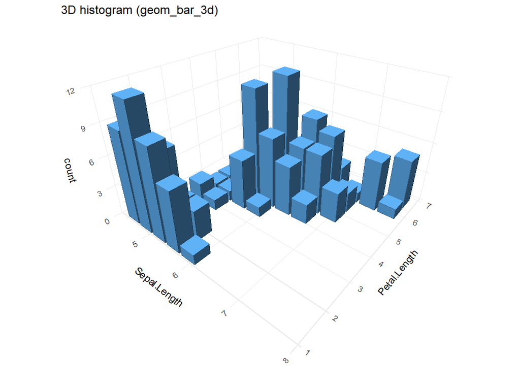

```r
p4 <- ggplot(iris, aes(x = Sepal.Length, y = Petal.Length)) +
  geom_bar_3d(
    fill  = "steelblue",
    color = "steelblue4",
    bins  = 10,
    width = c(0.85, 0.85)
  ) +
  coord_3d(yaw = 40, ratio = c(1, 1, 0.6), dist = 1.6) +
  scale_z_continuous(expand = c(0, 0)) +
  labs(title = "3D histogram (geom_bar_3d)") +
  theme_minimal()
p4
```

**`geom_col_3d()`** draws 3D columns directly from grid data with an explicit z height. Here a small categorical dataset is simulated — `site` is a station, `month` is the month, `precip` is rainfall — extending a 2D bar chart into three dimensions.

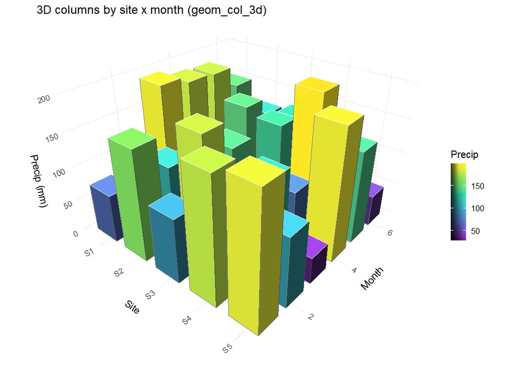

```r
set.seed(123)
col_data <- expand.grid(site = 1:5, month = 1:6)
col_data$precip <- round(runif(nrow(col_data), 20, 200))

p4b <- ggplot(col_data, aes(x = site, y = month, z = precip, fill = precip)) +
  geom_col_3d(width = 0.7) +
  scale_fill_viridis_c(option = "D") +
  coord_3d(yaw = 40, ratio = c(1, 1, 0.7)) +
  guides(fill = guide_colorbar_3d()) +
  scale_x_continuous(breaks = 1:5, labels = paste0("S", 1:5)) +
  labs(x = "Site", y = "Month", z = "Precip (mm)", fill = "Precip",
       title = "3D columns by site x month (geom_col_3d)") +
  theme_minimal()
p4b
```

# 7 3D paths through space and time

Many processes are not static but move and evolve: heatwave centres shifting, rain bands advancing, drought expanding, typhoon tracks changing, pollutant transport, water-mass migration, cloud or vapour-flux propagation. These are a natural fit for a 3D path.

Here a propagation trajectory is simulated — moving north-east with a fluctuating intensity. `lon` and `lat` are spatial position, `time` is the z (time) layer and `intensity` is event strength. A grey path projected onto the floor face acts as a “ground shadow”, making the horizontal movement easy to read.

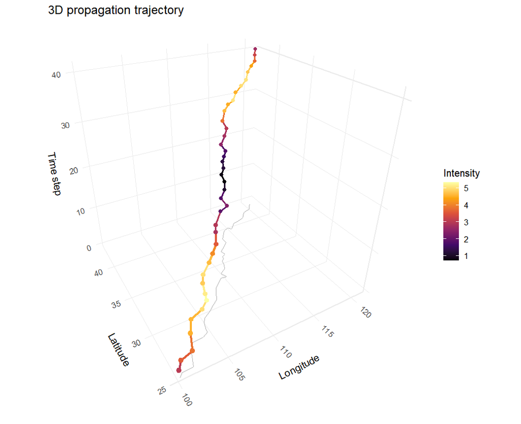

```r
set.seed(123)
n <- 40
track <- data.frame(time = 1:n)
track$lon <- 100 + cumsum(rnorm(n, 0.5, 0.4))
track$lat <- 25  + cumsum(rnorm(n, 0.45, 0.35))
track$intensity <- 3 + 2 * sin(seq(0, 3 * pi, length.out = n)) + rnorm(n, 0, 0.3)

p5 <- ggplot(track, aes(x = lon, y = lat, z = time, color = intensity)) +
  # ground projection (shadow on the floor face)
  geom_path_3d(linewidth = 0.4, color = "grey70",
               position = position_on_face("zmin")) +
  # the 3D trajectory itself + nodes
  geom_path_3d(linewidth = 1) +
  geom_point_3d(size = 2.2) +
  scale_color_viridis_c(option = "B") +
  coord_3d() +
  labs(x = "Longitude", y = "Latitude", z = "Time step",
       color = "Intensity", title = "3D propagation trajectory") +
  theme_minimal()
p5
```

> **Plugging in a real province shapefile (optional).** To replace the random track with real data, read province boundaries with `sf`, repeat the boundary coordinates for each time slice with the matching `z` (time) value, and overlay another `geom_path_3d()`:

> ```r
> # library(sf)
> # prov <- st_read("china_provinces.shp")
> # prov_df <- as.data.frame(st_coordinates(prov))
> # names(prov_df)[1:2] <- c("lon", "lat")
> ```

# 8 Stacked surface layers in one cube (the multi-index style)

## 8.1 Step 1 — one panel, three stacked layers

We simulate three index fields as progressively smaller regular grids, flatten their vertical relief, and offset them to well-separated base heights. The upper sheets are slightly smaller than the lower sheet, and a small planar tilt is added inside `z`. This keeps the original `coord_3d()` view while making each layer read as a separated, inclined spatial sheet rather than a large horizontal cover that hides the one below it.

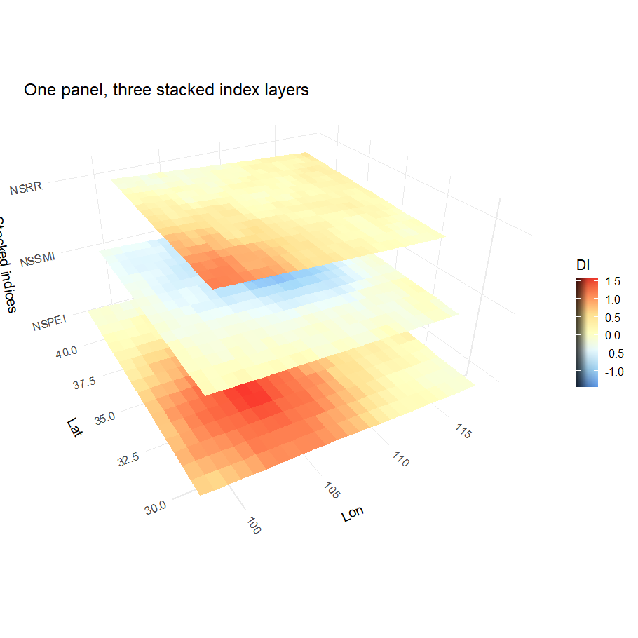

```r
set.seed(7)
layer_gap <- 12
z_relief  <- 0.18

# one index field: a Gaussian anomaly + low-frequency undulation on a smaller complete grid
make_layer <- function(cx, cy, sx, sy, amp, base, sheet_cx, sheet_cy, rx, ry, tilt_x, tilt_y) {
  g <- expand.grid(
    lon = seq(sheet_cx - rx, sheet_cx + rx, length.out = 26),
    lat = seq(sheet_cy - ry, sheet_cy + ry, length.out = 18)
  )
  g$val <- amp * exp(-(((g$lon - cx) / sx)^2 + ((g$lat - cy) / sy)^2)) +
           0.3 * sin(g$lon / 5) * cos(g$lat / 4) +
           rnorm(nrow(g), 0, 0.12)
  nx <- (g$lon - sheet_cx) / rx
  ny <- (g$lat - sheet_cy) / ry
  g$z <- base + g$val * z_relief + tilt_x * nx + tilt_y * ny
  g
}

L1 <- make_layer(104, 33, 7, 5,  1.6, 0,             108, 35, 10.2, 6.0, -0.75, 0.55) # NSPEI-like
L2 <- make_layer(110, 37, 6, 4, -1.4, layer_gap,     108, 35,  9.0, 5.2, -0.85, 0.60) # NSSMI-like
L3 <- make_layer( 99, 31, 8, 6,  1.2, 2 * layer_gap, 108, 35,  7.8, 4.6, -0.95, 0.65) # NSRR-like

p6a <- ggplot(mapping = aes(x = lon, y = lat, z = z, fill = val, color = val)) +
  geom_surface_3d(data = L1, linewidth = 0.03) +
  geom_surface_3d(data = L2, linewidth = 0.03) +
  geom_surface_3d(data = L3, linewidth = 0.03) +
  scale_fill_distiller(palette = "RdYlBu") +    # blue = wet, red = dry (flip with direction = -1)
  scale_color_distiller(palette = "RdYlBu") +
  scale_z_continuous(breaks = c(0, layer_gap, 2 * layer_gap),
                     labels = function(z) c("NSPEI", "NSSMI", "NSRR")[match(round(z, 6), round(c(0, layer_gap, 2 * layer_gap), 6))]) +
  coord_3d(ratio = c(1, 1, 0.6)) +
  guides(fill = guide_colorbar_3d(), color = "none") +
  labs(x = "Lon", y = "Lat", z = "Stacked indices", fill = "DI",
       title = "One panel, three stacked index layers") +
  theme_minimal()
p6a
```

## 8.2 Step 2 — extend to a 3 x 3 grid, three layers per panel

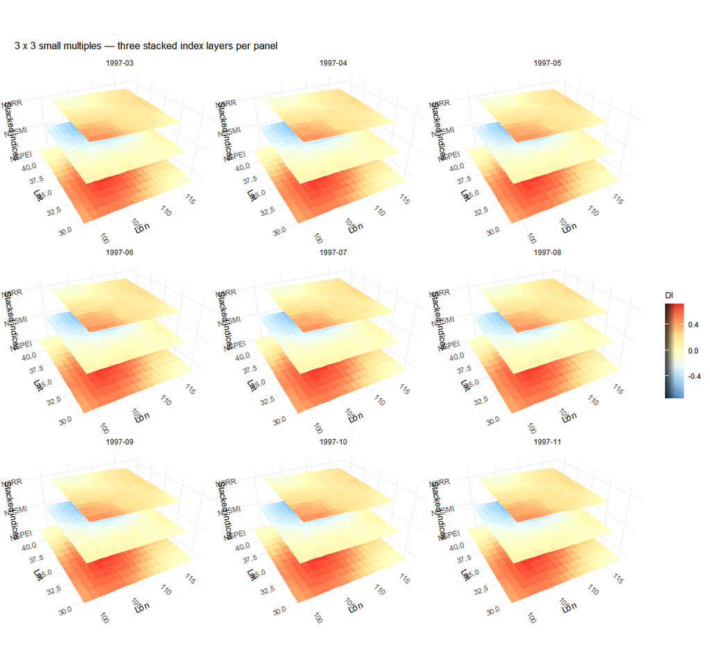

```r
set.seed(11)
months <- sprintf("1997-%02d", 3:11)        # 9 months -> 3 x 3

# build one index layer across all months: centre drifts (dx, dy) and amplitude swings seasonally
layer_gap_f <- 10
z_relief_f  <- 0.16
make_layer_t <- function(cx0, cy0, sx, sy, amp, base, dx, dy, phase,
                         sheet_cx, sheet_cy, rx, ry, tilt_x, tilt_y) {
  do.call(rbind, lapply(seq_along(months) - 1, function(k) {
    g  <- expand.grid(
      lon = seq(sheet_cx - rx, sheet_cx + rx, length.out = 18),
      lat = seq(sheet_cy - ry, sheet_cy + ry, length.out = 14)
    )
    cx <- cx0 + k * dx
    cy <- cy0 + k * dy
    a  <- amp * (0.55 + 0.45 * sin(k / 2 + phase))
    g$val <- a * exp(-(((g$lon - cx) / sx)^2 + ((g$lat - cy) / sy)^2)) +
             0.25 * sin(g$lon / 5) * cos(g$lat / 4) +
             rnorm(nrow(g), 0, 0.10)
    nx <- (g$lon - sheet_cx) / rx
    ny <- (g$lat - sheet_cy) / ry
    g$z     <- base + g$val * z_relief_f + tilt_x * nx + tilt_y * ny
    g$month <- factor(months[k + 1], levels = months)
    g
  }))
}

S1 <- make_layer_t(100, 32, 7, 5,  1.6, 0,                 1.4, 0.7, 0, 108, 35, 9.8, 5.8, -0.70, 0.50)
S2 <- make_layer_t(112, 38, 6, 4, -1.4, layer_gap_f,      -1.0, 0.3, 1, 108, 35, 8.6, 5.0, -0.80, 0.55)
S3 <- make_layer_t( 98, 30, 8, 6,  1.2, 2 * layer_gap_f,   1.1, 0.6, 2, 108, 35, 7.4, 4.4, -0.90, 0.60)

p6b <- ggplot(mapping = aes(x = lon, y = lat, z = z, fill = val, color = val)) +
  geom_surface_3d(data = S1, linewidth = 0.02) +
  geom_surface_3d(data = S2, linewidth = 0.02) +
  geom_surface_3d(data = S3, linewidth = 0.02) +
  facet_wrap(~ month, ncol = 3) +
  scale_fill_distiller(palette = "RdYlBu") +
  scale_color_distiller(palette = "RdYlBu") +
  scale_z_continuous(breaks = c(0, layer_gap_f, 2 * layer_gap_f),
                     labels = function(z) c("NSPEI", "NSSMI", "NSRR")[match(round(z, 6), round(c(0, layer_gap_f, 2 * layer_gap_f), 6))]) +
  coord_3d(ratio = c(1, 1, 0.6)) +
  guides(fill = guide_colorbar_3d(), color = "none") +
  labs(x = "Lon", y = "Lat", z = "Stacked indices", fill = "DI",
       title = "3 x 3 small multiples — three stacked index layers per panel") +
  theme_minimal(base_size = 8) +
  theme(legend.position = "right")
p6b
```

> **Notes.** (1) Use *one* `geom_surface_3d()` per layer, each with its own complete grid — don’t put three `z` values on the same `(lon, lat)` in a single frame, or the surface stat can’t tessellate a single-valued grid. (2) Map color to the index *value*, but map height (`z`) to `base + value * z_relief + tilt`; this keeps the sheets thin, inclined and separated, avoiding top-layer occlusion. (3) Tune `layer_gap` upward for more separation, tune `z_relief` downward for flatter sheets, or reduce `rx / ry` to make each complete layer grid smaller. (4) This is render-heavy (panels x layers x grid cells) — keep the per-panel grid modest. (5) For the real “masked basin” look, swap the simulated fields for an open gridded index — **SPEI** (CSIC), **CRU TS**, **TerraClimate**, or SPI/SPEI from **ERA5-Land** (Copernicus). For `geom_surface_3d()`, prefer cropping/resampling each layer to a complete regular grid before plotting; sparse `NA` masks can create incomplete surface strips that some ggcube versions cannot group reliably:

> ```r
> # library(sf)
> # basin <- st_read("basin.gpkg")
> # bbox  <- st_bbox(basin)
> # lon   <- seq(bbox["xmin"], bbox["xmax"], length.out = 30)
> # lat   <- seq(bbox["ymin"], bbox["ymax"], length.out = 20)
> # layer <- expand.grid(lon = lon, lat = lat)  # complete grid for geom_surface_3d()
> ```

# 9 Exporting thumbnails

```r
out_dir <- "../fig/projects"
if (!dir.exists(out_dir)) dir.create(out_dir, recursive = TRUE)

ggsave(file.path(out_dir, "09-ggcube-scatter.png"), p1,  width = 8, height = 6,   dpi = 150)
ggsave(file.path(out_dir, "09-ggcube-weather.png"), p2,  width = 8, height = 6,   dpi = 150)
ggsave(file.path(out_dir, "09-ggcube-dem.png"),     p3,  width = 8, height = 6.5, dpi = 150)
ggsave(file.path(out_dir, "09-ggcube-bar.png"),     p4,  width = 8, height = 6,   dpi = 150)
ggsave(file.path(out_dir, "09-ggcube-path.png"),    p5,  width = 8, height = 6.5, dpi = 150)
ggsave(file.path(out_dir, "09-ggcube-stack.png"),   p6a, width = 7, height = 7,   dpi = 150)
ggsave(file.path(out_dir, "09-ggcube-facets.png"),  p6b, width = 9, height = 8.5, dpi = 150)
```

# 10 Summary

`ggcube` extends the familiar ggplot2 grammar into three dimensions: just add `z` to `aes()`, swap `geom_*()` for the matching `geom_*_3d()`, and append `coord_3d()` to obtain scatter, surface, bar and path figures — with support for lighting, viewpoint control and mixed 2D/3D layers. For hydro-meteorological and geographic data that carry space, time and intensity together, this is a low-friction, reproducible visualization approach that plugs straight into an existing ggplot2 workflow.

*Package: [ggcube](https://matthewkling.github.io/ggcube/) by Matthew Kling.*